# Homework 03

Logistic Regression

Chaoqun Yin

September 11, 2018

# Data analysis

### 1992 presidential election

The folder `nes` contains the survey data of presidential preference and income for the 1992 election analyzed in Section 5.1, along with other variables including sex, ethnicity, education, party identification, and political ideology.

1. Fit a logistic regression predicting support for Bush given all these inputs. Consider how to include these as regression predictors and also consider possible interactions.

```r
library(dplyr)
#Convert the strings to integers
nes5200_dt_s$gender <- as.integer(nes5200_dt_s$gender)
nes5200_dt_s$race <- as.integer(nes5200_dt_s$race)
nes5200_dt_s$educ1 <- as.integer(nes5200_dt_s$educ1)
nes5200_dt_s$income <- as.integer(nes5200_dt_s$income)
nes5200_dt_s$partyid7 <- as.integer(nes5200_dt_s$partyid7)
nes5200_dt_s$ideo_feel <- as.integer(nes5200_dt_s$ideo_feel)
#Create new dataset to conduct analysis
nes5200_dt_s %>%
  select(vote_rep,gender,race,educ1,income,partyid7,ideo_feel) -> nes5200.analysis
#Omit useless data
nes5200.new = na.omit(nes5200.analysis)
#GLM model
nes5200.fit.1 <- glm(vote_rep ~ gender+race+income+educ1+partyid7+ideo_feel,family = binomial,data = nes5200.new)
summary(nes5200.fit.1)
```

```
##
## Call:
## glm(formula = vote_rep ~ gender + race + income + educ1 + partyid7 +
##     ideo_feel, family = binomial, data = nes5200.new)
##
## Deviance Residuals:
##     Min       1Q   Median       3Q      Max
## -3.4016  -0.3866  -0.1462   0.3215   2.7018
##
## Coefficients:
##              Estimate Std. Error z value Pr(>|z|)
## (Intercept) -10.68194    1.04004 -10.271   <2e-16 ***
## gender        0.39685    0.21253   1.867   0.0619 .
## race          0.13649    0.09959   1.371   0.1705
## income       -0.08294    0.10699  -0.775   0.4382
## educ1         0.03415    0.12381   0.276   0.7827
## partyid7      0.96386    0.06283  15.341   <2e-16 ***
## ideo_feel     0.08871    0.01054   8.421   <2e-16 ***
## ---
## Signif. codes:  0 '***' 0.001 '**' 0.01 '*' 0.05 '.' 0.1 ' ' 1
##
## (Dispersion parameter for binomial family taken to be 1)
##
##     Null deviance: 1523.84  on 1123  degrees of freedom
## Residual deviance:  634.22  on 1117  degrees of freedom
## AIC: 648.22
##
## Number of Fisher Scoring iterations: 6
```

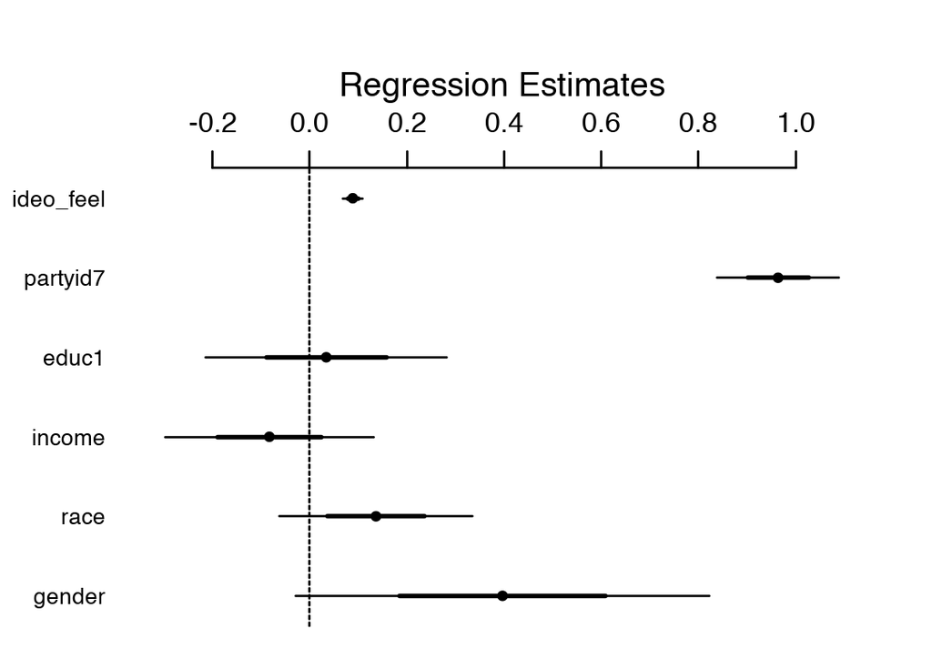

```r
#Model regression estimates plot
coefplot(nes5200.fit.1)
```

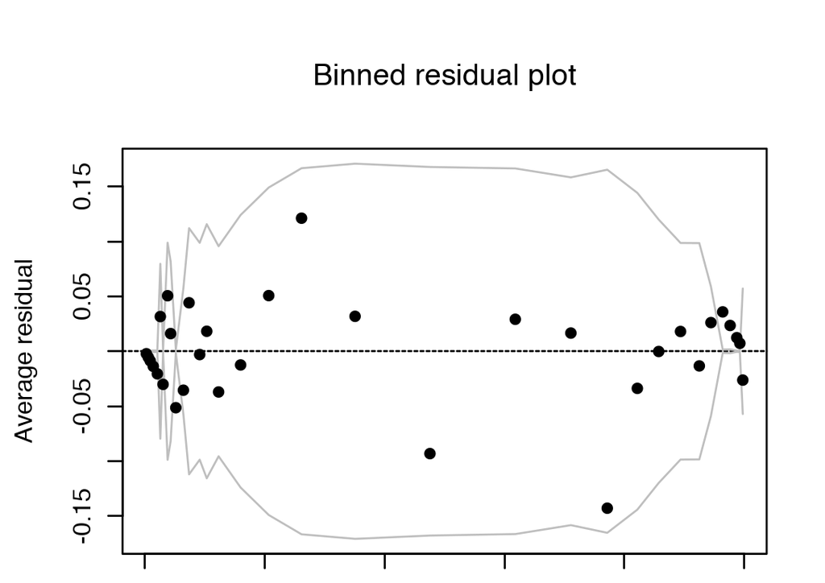

```r
#Binned residual plot
binnedplot(fitted(nes5200.fit.1),resid(nes5200.fit.1,type = "response"))
```

2. Evaluate and compare the different models you have fit. Consider coefficient estimates and standard errors, residual plots, and deviances.

```r
#model with the interaction of income and educ1
nes5200.fit.2 <- glm(vote_rep~gender+race+income*educ1+partyid7+ideo_feel,family = binomial,data=nes5200.new)
summary(nes5200.fit.2)
```

```
##
## Call:
## glm(formula = vote_rep ~ gender + race + income * educ1 + partyid7 +
##     ideo_feel, family = binomial, data = nes5200.new)
##
## Deviance Residuals:
##     Min       1Q   Median       3Q      Max
## -3.3906  -0.3831  -0.1433   0.3209   2.6970
##
## Coefficients:
##               Estimate Std. Error z value Pr(>|z|)
## (Intercept)  -11.44123    1.64788  -6.943 3.84e-12 ***
## gender         0.40012    0.21262   1.882   0.0599 .
## race           0.13841    0.09987   1.386   0.1658
## income         0.15485    0.41042   0.377   0.7060
## educ1          0.23747    0.36034   0.659   0.5099
## partyid7       0.96283    0.06287  15.314  < 2e-16 ***
## ideo_feel      0.08915    0.01058   8.427  < 2e-16 ***
## income:educ1  -0.06428    0.10695  -0.601   0.5478
## ---
## Signif. codes:  0 '***' 0.001 '**' 0.01 '*' 0.05 '.' 0.1 ' ' 1
##
## (Dispersion parameter for binomial family taken to be 1)
##
##     Null deviance: 1523.84  on 1123  degrees of freedom
## Residual deviance:  633.86  on 1116  degrees of freedom
## AIC: 649.86
##
## Number of Fisher Scoring iterations: 6
```

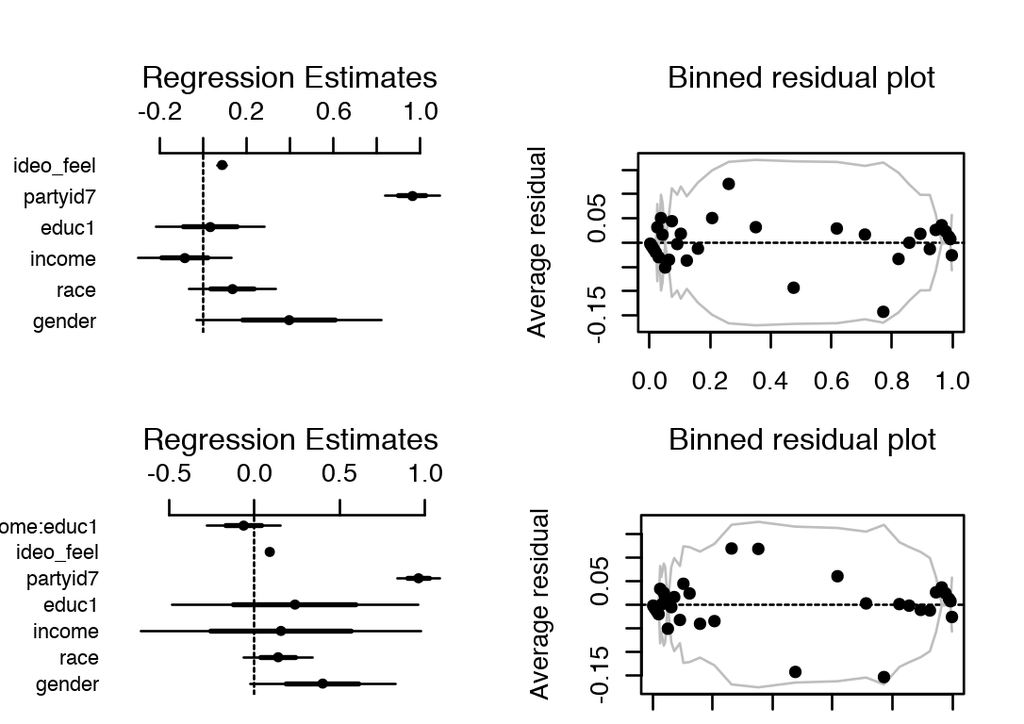

```r
#Compare the plot
par(mfrow=c(2,2))
coefplot(nes5200.fit.1)
binnedplot(fitted(nes5200.fit.1),resid(nes5200.fit.1,type = "response"))
coefplot(nes5200.fit.2)
binnedplot(fitted(nes5200.fit.2),resid(nes5200.fit.2,type = "response"))
```

3. For your chosen model, discuss and compare the importance of each input variable in the prediction. For all the significant variables in this model 2:
- Intercept: if a person has categories with the gender of 0 value, and the same with race, income, educ1, partyid7, and ideo_feel, the preson will have log odds of −11.44 to vote for Bush.
- Partyid7: holding all other variables, if partyid7 increase by 1 category, the expected value of the voter’s log odds for Bush will increase by 0.96 unit.
- ideo_feel: holding all other variables, if ideo_feel increase by 1 unit, the expected value of the voter’s log odds for Bush will increase by 0.08 unit.

```r
summary(nes5200.fit.2)
```

```
##
## Call:
## glm(formula = vote_rep ~ gender + race + income * educ1 + partyid7 +
##     ideo_feel, family = binomial, data = nes5200.new)
##
## Deviance Residuals:
##     Min       1Q   Median       3Q      Max
## -3.3906  -0.3831  -0.1433   0.3209   2.6970
##
## Coefficients:
##               Estimate Std. Error z value Pr(>|z|)
## (Intercept)  -11.44123    1.64788  -6.943 3.84e-12 ***
## gender         0.40012    0.21262   1.882   0.0599 .
## race           0.13841    0.09987   1.386   0.1658
## income         0.15485    0.41042   0.377   0.7060
## educ1          0.23747    0.36034   0.659   0.5099
## partyid7       0.96283    0.06287  15.314  < 2e-16 ***
## ideo_feel      0.08915    0.01058   8.427  < 2e-16 ***
## income:educ1  -0.06428    0.10695  -0.601   0.5478
## ---
## Signif. codes:  0 '***' 0.001 '**' 0.01 '*' 0.05 '.' 0.1 ' ' 1
##
## (Dispersion parameter for binomial family taken to be 1)
##
##     Null deviance: 1523.84  on 1123  degrees of freedom
## Residual deviance:  633.86  on 1116  degrees of freedom
## AIC: 649.86
##
## Number of Fisher Scoring iterations: 6
```

### Graphing logistic regressions:

the well-switching data described in Section 5.4 of the Gelman and Hill are in the folder `arsenic`.

1. Fit a logistic regression for the probability of switching using log (distance to nearest safe well) as a predictor.

```r
model.wells <- glm(switch~log(dist),family =binomial(link = "logit"),data = wells_dt)
summary(model.wells)
```

```
##
## Call:
## glm(formula = switch ~ log(dist), family = binomial(link = "logit"),
##     data = wells_dt)
##
## Deviance Residuals:
##     Min       1Q   Median       3Q      Max
## -1.6365  -1.2795   0.9785   1.0616   1.2220
##
## Coefficients:
##             Estimate Std. Error z value Pr(>|z|)
## (Intercept)  1.01971    0.16314   6.251 4.09e-10 ***
## log(dist)   -0.20044    0.04428  -4.526 6.00e-06 ***
## ---
## Signif. codes:  0 '***' 0.001 '**' 0.01 '*' 0.05 '.' 0.1 ' ' 1
##
## (Dispersion parameter for binomial family taken to be 1)
##
##     Null deviance: 4118.1  on 3019  degrees of freedom
## Residual deviance: 4097.3  on 3018  degrees of freedom
## AIC: 4101.3
##
## Number of Fisher Scoring iterations: 4
```

2. Make a graph similar to Figure 5.9 of the Gelman and Hill displaying Pr(switch) as a function of distance to nearest safe well, along with the data.

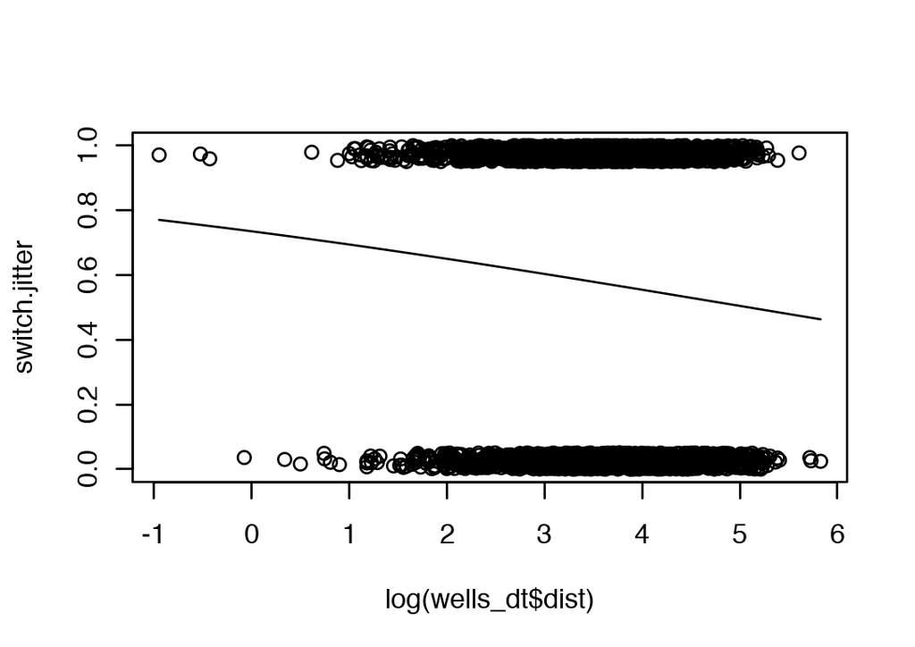

```r
jitter.binary <- function(a, jitt=.05){
ifelse (a==0, runif (length(a), 0, jitt), runif (length(a), 1-jitt, 1))
}

switch.jitter <- jitter.binary (wells_dt$switch)
plot (log(wells_dt$dist), switch.jitter)
curve (invlogit (coef(model.wells)[1] + coef(model.wells)[2]*x), add=TRUE)
```

3. Make a residual plot and binned residual plot as in Figure 5.13.

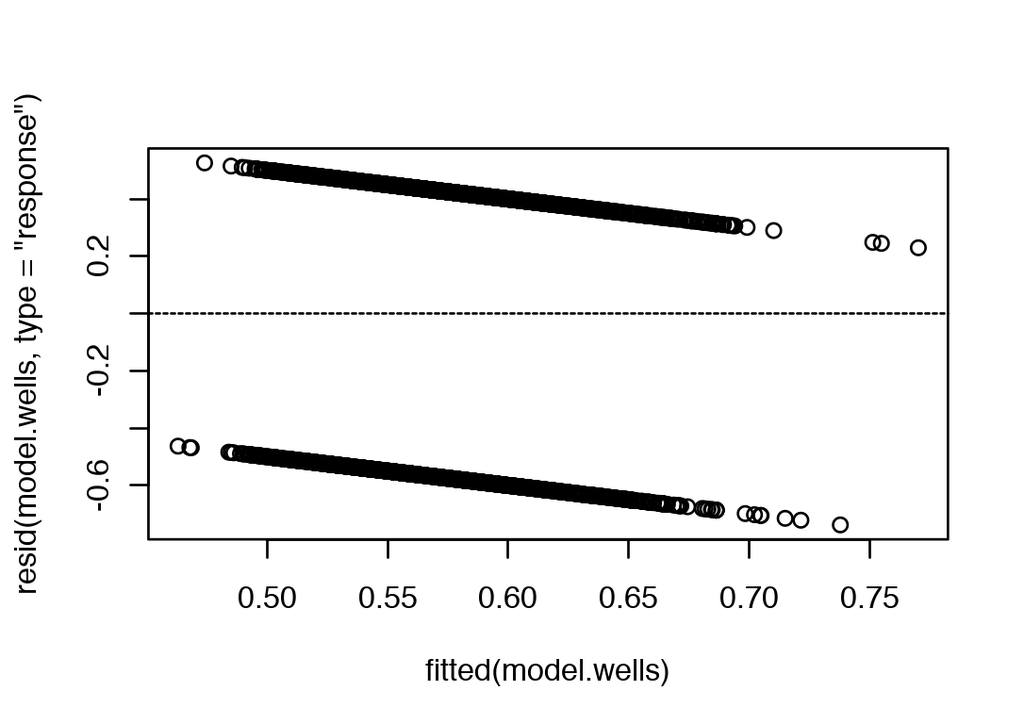

```r
plot(fitted(model.wells),resid(model.wells,type="response"))
abline(h=0,lty=2)
```

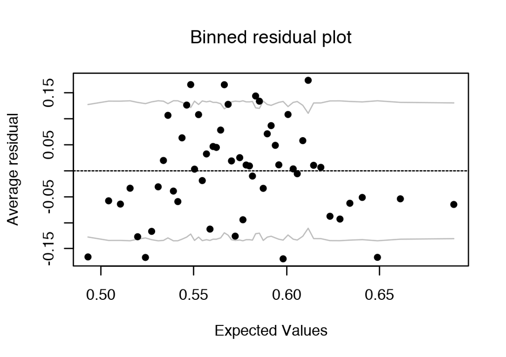

```r
binnedplot(fitted(model.wells),resid(model.wells,type="response"))
```

4. Compute the error rate of the fitted model and compare to the error rate of the null model.

```r
predicted <- fitted(model.wells)
error.rate <- mean ((predicted>0.5 & wells_dt$switch==0) | (predicted<.5 & wells_dt$switch==1))
error.rate.null <- min(mean(wells_dt$switch),1-mean(wells_dt$switch))
error.rate
```

```
## [1] 0.4192053
```

```r
error.rate.null
```

```
## [1] 0.4248344
```

The error rate between the model and the null model is similar.

5. Create indicator variables corresponding to `dist < 100`, `100 =< dist < 200`, and `dist > 200`. Fit a logistic regression for Pr(switch) using these indicators. With this new model, repeat the computations and graphs for part (1) of this exercise.

```r
dist_wells <- wells_dt$dist
dist_wells[dist_wells<100] <- 1
dist_wells[dist_wells>=100 & dist_wells<200] <- 2
dist_wells[dist_wells>=200] <- 3
model.pr <- glm(switch~dist_wells,family=binomial(link="logit"),data = wells_dt)
summary(model.pr)
```

```
##
## Call:
## glm(formula = switch ~ dist_wells, family = binomial(link = "logit"),
##     data = wells_dt)
##
## Deviance Residuals:
##    Min      1Q  Median      3Q     Max
## -1.340  -1.340   1.023   1.023   1.606
##
## Coefficients:
##             Estimate Std. Error z value Pr(>|z|)
## (Intercept)   1.0456     0.1353   7.727 1.10e-14 ***
## dist_wells   -0.6712     0.1178  -5.697 1.22e-08 ***
## ---
## Signif. codes:  0 '***' 0.001 '**' 0.01 '*' 0.05 '.' 0.1 ' ' 1
##
## (Dispersion parameter for binomial family taken to be 1)
##
##     Null deviance: 4118.1  on 3019  degrees of freedom
## Residual deviance: 4084.8  on 3018  degrees of freedom
## AIC: 4088.8
##
## Number of Fisher Scoring iterations: 4
```

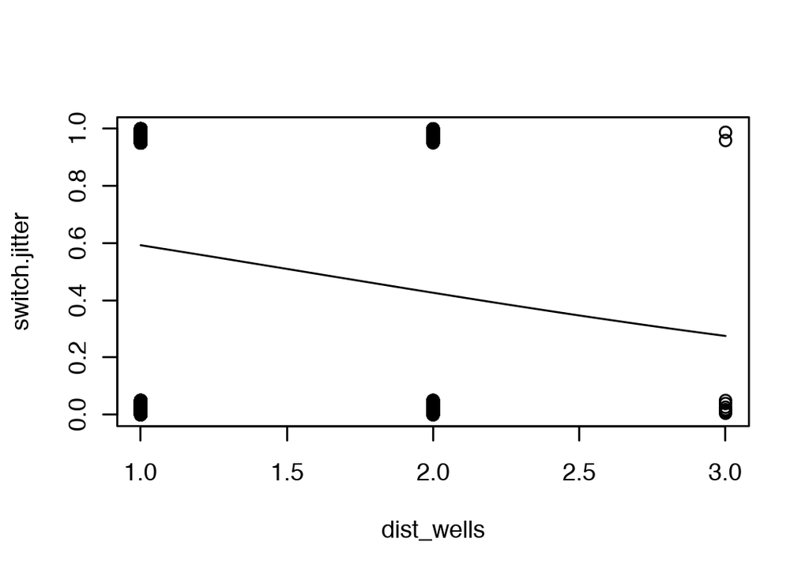

```r
#graph with fitted model and jitter points
jitter.binary <- function(a, jitt=.05){
ifelse (a==0, runif (length(a), 0, jitt), runif (length(a), 1-jitt, 1))
}

switch.jitter <- jitter.binary (wells_dt$switch)
plot (dist_wells, switch.jitter)
curve (invlogit (coef(model.pr)[1] + coef(model.pr)[2]*x), add=TRUE)
```

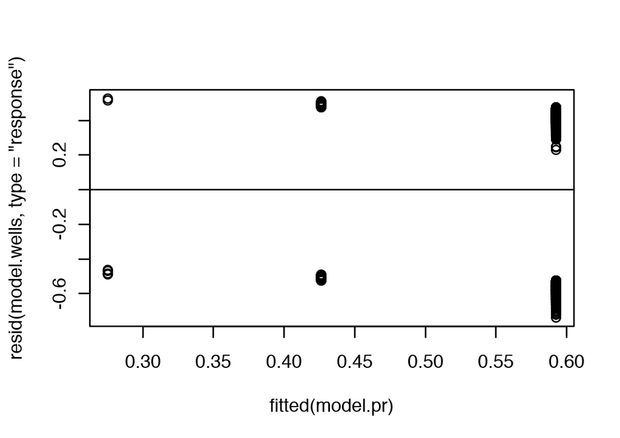

```r
#residual plots
plot(fitted(model.pr),resid(model.wells,type="response"))
abline(h=0)
```

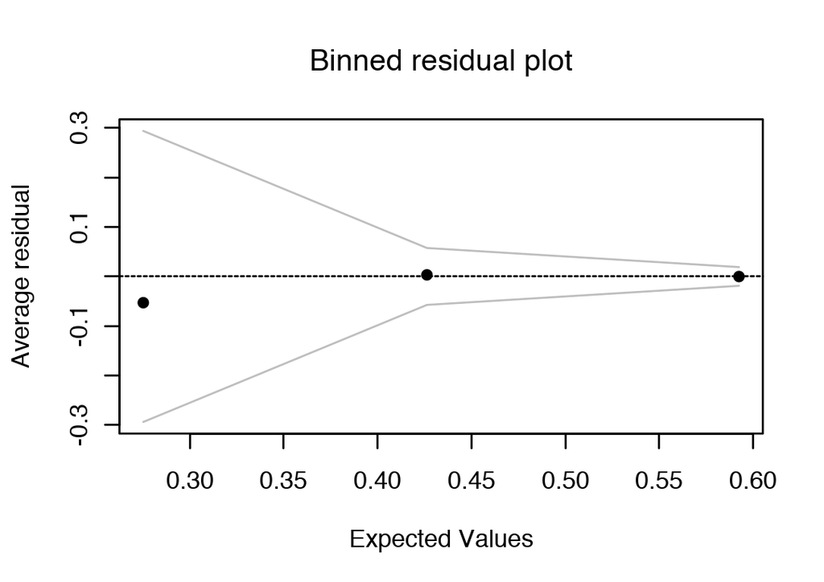

```r
#Binned residual plot
binnedplot(fitted(model.pr),resid(model.pr,type="response"))
```

```r
#error rate
predicted <- fitted(model.pr)
error.rate <- mean ((predicted>0.5 & wells_dt$switch==0) | (predicted<.5 & wells_dt$switch==1))
error.rate.null <- min(mean(wells_dt$switch),1-mean(wells_dt$switch))
error.rate
```

```
## [1] 0.4092715
```

```r
error.rate.null
```

```
## [1] 0.4248344
```

The error rate gets better.

### Model building and comparison:

continue with the well-switching data described in the previous exercise.

1. Fit a logistic regression for the probability of switching using, as predictors, distance, `log(arsenic)`, and their interaction. Interpret the estimated coefficients and their standard errors.

```r
model.switch <- glm(switch~dist+log(arsenic)+dist*log(arsenic),family = binomial(link="logit"),data = wells_dt)
summary(model.switch)
```

```
##
## Call:
## glm(formula = switch ~ dist + log(arsenic) + dist * log(arsenic),
##     family = binomial(link = "logit"), data = wells_dt)
##
## Deviance Residuals:
##     Min       1Q   Median       3Q      Max
## -2.1814  -1.1642   0.7468   1.0470   1.8383
##
## Coefficients:
##                    Estimate Std. Error z value Pr(>|z|)
## (Intercept)        0.491350   0.068119   7.213 5.47e-13 ***
## dist              -0.008735   0.001342  -6.510 7.52e-11 ***
## log(arsenic)       0.983414   0.109694   8.965  < 2e-16 ***
## dist:log(arsenic) -0.002309   0.001826  -1.264    0.206
## ---
## Signif. codes:  0 '***' 0.001 '**' 0.01 '*' 0.05 '.' 0.1 ' ' 1
##
## (Dispersion parameter for binomial family taken to be 1)
##
##     Null deviance: 4118.1  on 3019  degrees of freedom
## Residual deviance: 3896.8  on 3016  degrees of freedom
## AIC: 3904.8
##
## Number of Fisher Scoring iterations: 4
```

- Interpret: Controlling the distance is 0 and arsenic is 1, the log odds of switch is 0.49. If holding other variables, one unit increase in distance will lead to a decrease of 0.008 unit on log odds of switch. If holding other variables, one unit increase in log(arsenic) will lead to an increase of 0.98 unit on log odds of switch.If we hold other variables, one unit increase in dist*log(arsenic) will lead to a decrease of 0.0023 on log odds of switch.
- Standard error:

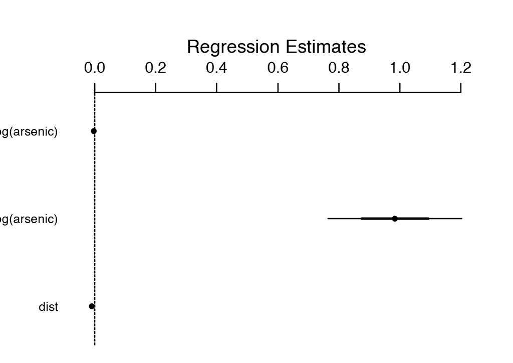

```r
coefplot(model.switch)
```

2. Make graphs as in Figure 5.12 to show the relation between probability of switching, distance, and arsenic level.

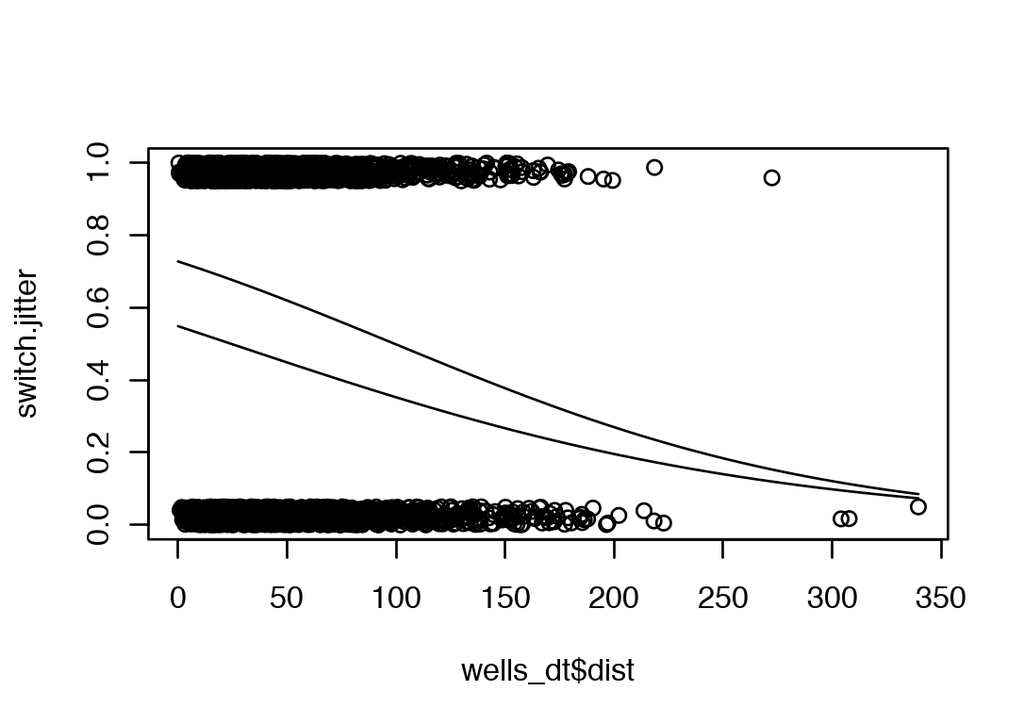

```r
plot(wells_dt$dist,switch.jitter,xlim=c(0,max(wells_dt$dist)))
curve(invlogit(cbind(1,x,0.5,0.5*x) %*% coef(model.switch)),add=TRUE)
curve(invlogit(cbind(1,x,-0.3,-0.3*x) %*% coef(model.switch)),add=TRUE)
```

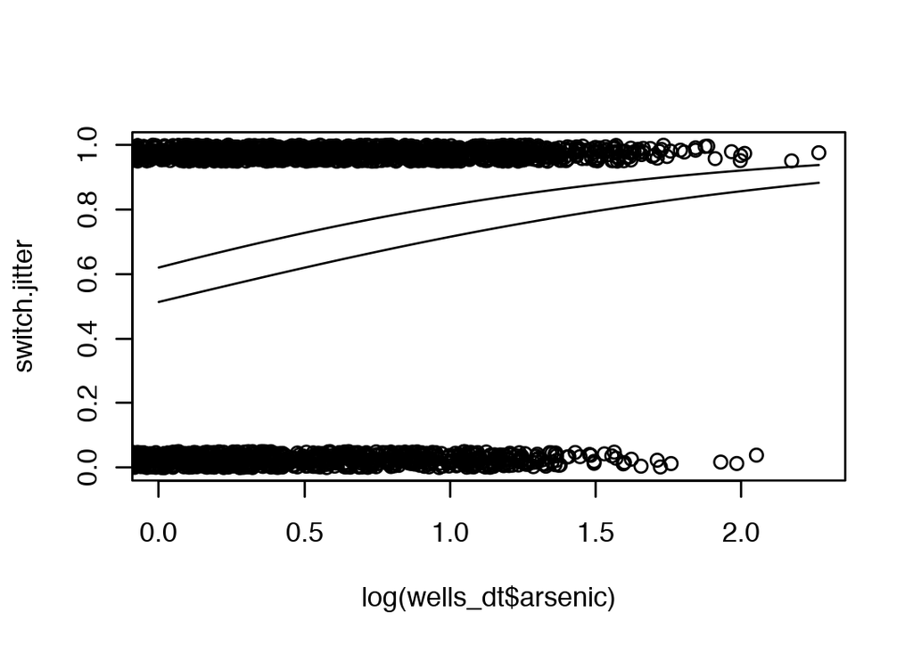

```r
plot(log(wells_dt$arsenic),switch.jitter,xlim=c(0,max(log(wells_dt$arsenic))))
curve(invlogit(cbind(1,0,x,0) %*% coef(model.switch)),add=TRUE)
curve(invlogit(cbind(1,50,x,50*x) %*% coef(model.switch)),add=TRUE)
```

3. Following the procedure described in Section 5.7, compute the average predictive differences corresponding to:
1. A comparison of dist = 0 to dist = 100, with arsenic held constant.
2. A comparison of dist = 100 to dist = 200, with arsenic held constant.
3. A comparison of arsenic = 0.5 to arsenic = 1.0, with dist held constant.
4. A comparison of arsenic = 1.0 to arsenic = 2.0, with dist held constant. Discuss these results.

```r
#A comparison of dist = 0 to dist = 100
b <- coef (model.switch)
h <- 100
l <- 0
delta <- invlogit (b[1] + b[2]*h + b[3]*log(wells_dt$arsenic) + b[4]*(h*log(wells_dt$arsenic))) -
  invlogit (b[1] + b[2]*l + b[3]*log(wells_dt$arsenic) + b[4]*(l*log(wells_dt$arsenic)))
(mean(delta))
```

```
## [1] -0.2113356
```

```r
#A comparison of dist = 100 to dist = 200
h <- 200
l <- 100
delta <- invlogit (b[1] + b[2]*h + b[3]*log(wells_dt$arsenic) + b[4]*(h*log(wells_dt$arsenic))) -
  invlogit (b[1] + b[2]*l + b[3]*log(wells_dt$arsenic) + b[4]*(l*log(wells_dt$arsenic)))
(mean(delta))
```

```
## [1] -0.2090207
```

```r
#A comparison of arsenic = 0.5 to arsenic = 1.0
h <- 1.0
l <- 0.5
delta <- invlogit (b[1] + b[2]*wells_dt$dist + b[3]*log(h) + b[4]*(wells_dt$dist*log(h))) -
  invlogit (b[1] + b[2]*wells_dt$dist + b[3]*log(l) + b[4]*(wells_dt$dist*log(l)))
(mean(delta))
```

```
## [1] 0.1460174
```

```r
#A comparison of arsenic = 1.0 to arsenic = 2.0
h <- 2.0
l <- 1.0
delta <- invlogit (b[1] + b[2]*wells_dt$dist + b[3]*log(h) + b[4]*(wells_dt$dist*log(h))) -
  invlogit (b[1] + b[2]*wells_dt$dist + b[3]*log(l) + b[4]*(wells_dt$dist*log(l)))
(mean(delta))
```

```
## [1] 0.1404344
```

### Building a logistic regression model:

the folder rodents contains data on rodents in a sample of New York City apartments.

Please read for the data details. http://www.stat.columbia.edu/~gelman/arm/examples/rodents/rodents.doc

1. Build a logistic regression model to predict the presence of rodents (the variable y in the dataset) given indicators for the ethnic groups (race). Combine categories as appropriate. Discuss the estimated coefficients in the model.

```r
apt_dt$race <- factor(apt_dt$race, labels=c("White (non-hispanic)", "Black (non-hispanic)", "Puerto Rican", "Other Hispanic", "Asian/Pacific Islander", "Amer-Indian/Native Alaskan", "Two or more races"))
glm.apt <- glm(formula = y ~ race , data = apt_dt ,family = binomial(link = "logit"))
summary(glm.apt)
```

```
##
## Call:
## glm(formula = y ~ race, family = binomial(link = "logit"), data = apt_dt)
##
## Deviance Residuals:
##     Min       1Q   Median       3Q      Max
## -1.1774  -0.8969  -0.4690  -0.4690   2.1270
##
## Coefficients:
##                                Estimate Std. Error z value Pr(>|z|)
## (Intercept)                     -2.1521     0.1281 -16.798  < 2e-16 ***
## raceBlack (non-hispanic)         1.5361     0.1687   9.108  < 2e-16 ***
## racePuerto Rican                 1.4492     0.2138   6.777 1.23e-11 ***
## raceOther Hispanic               1.8671     0.1872   9.973  < 2e-16 ***
## raceAsian/Pacific Islander       0.4004     0.2923   1.370  0.17080
## raceAmer-Indian/Native Alaskan   2.1521     0.8265   2.604  0.00922 **
## raceTwo or more races            0.7658     0.8009   0.956  0.33897
## ---
## Signif. codes:  0 '***' 0.001 '**' 0.01 '*' 0.05 '.' 0.1 ' ' 1
##
## (Dispersion parameter for binomial family taken to be 1)
##
##     Null deviance: 1672.2  on 1521  degrees of freedom
## Residual deviance: 1518.7  on 1515  degrees of freedom
##   (225 observations deleted due to missingness)
## AIC: 1532.7
##
## Number of Fisher Scoring iterations: 4
```

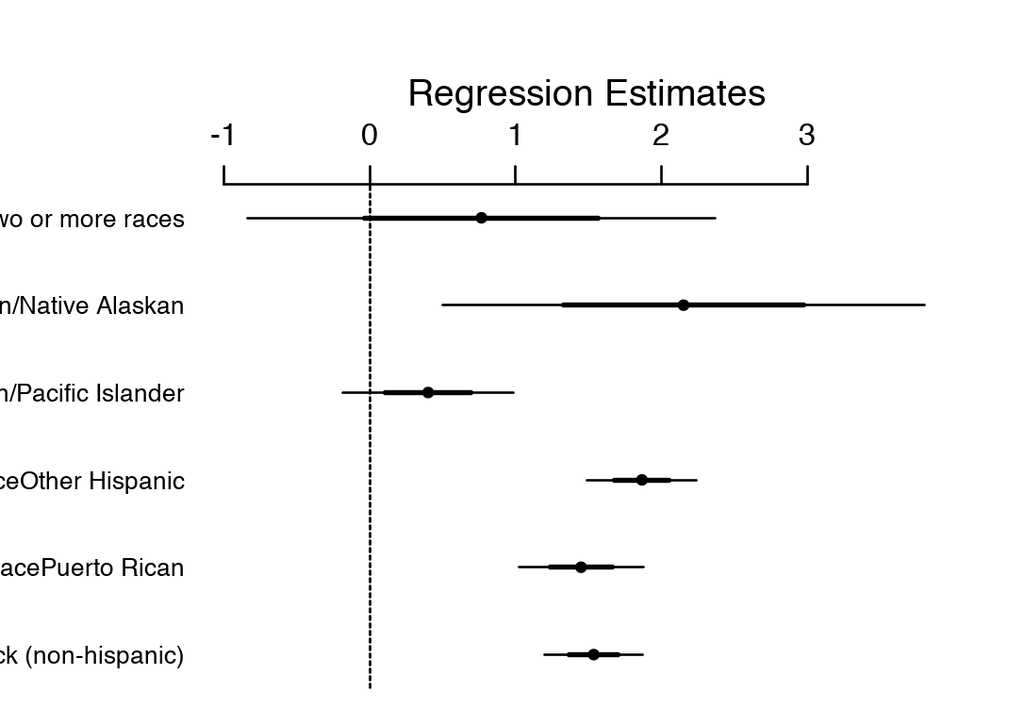

```r
coefplot(glm.apt)
```

Black(non-hispanic), Puerto Rican, Other Hispanic and Amer-Indian/Native Alaskan in race variables are significant which means they do have effects on the presence of rodents.

2. Add to your model some other potentially relevant predictors describing the apartment, building, and community district. Build your model using the general principles explained in Section 4.6 of the Gelman and Hill. Discuss the coefficients for the ethnicity indicators in your model.

```r
glm.apt.new <- glm(y ~ race + floor + dist + defects + poor + bldg, data = apt_dt, family = binomial(link = "logit"))
summary(glm.apt.new)
```

```
##
## Call:
## glm(formula = y ~ race + floor + dist + defects + poor + bldg,
##     family = binomial(link = "logit"), data = apt_dt)
##
## Deviance Residuals:
##     Min       1Q   Median       3Q      Max
## -2.0015  -0.6765  -0.4172  -0.2799   2.5167
##
## Coefficients:
##                                 Estimate Std. Error z value Pr(>|z|)
## (Intercept)                    -2.598797   0.302234  -8.599  < 2e-16 ***
## raceBlack (non-hispanic)        1.069659   0.186205   5.745 9.22e-09 ***
## racePuerto Rican                0.880083   0.244973   3.593 0.000327 ***
## raceOther Hispanic              1.468922   0.208976   7.029 2.08e-12 ***
## raceAsian/Pacific Islander      0.350589   0.312460   1.122 0.261851
## raceAmer-Indian/Native Alaskan  1.197037   0.946806   1.264 0.206126
## raceTwo or more races           0.821774   0.848111   0.969 0.332572
## floor                          -0.013997   0.037027  -0.378 0.705407
## dist                            0.047833   0.046796   1.022 0.306699
## defects                         0.462335   0.043984  10.511  < 2e-16 ***
## poor                            0.149509   0.049301   3.033 0.002425 **
## bldg                           -0.003436   0.002569  -1.338 0.180935
## ---
## Signif. codes:  0 '***' 0.001 '**' 0.01 '*' 0.05 '.' 0.1 ' ' 1
##
## (Dispersion parameter for binomial family taken to be 1)
##
##     Null deviance: 1672.2  on 1521  degrees of freedom
## Residual deviance: 1333.0  on 1510  degrees of freedom
##   (225 observations deleted due to missingness)
## AIC: 1357
##
## Number of Fisher Scoring iterations: 5
```

# Conceptual exercises.

### Shape of the inverse logit curve

Without using a computer, sketch the following logistic regression lines:

1. $Pr(y = 1) = logit^{-1}(x)$
2. $Pr(y = 1) = logit^{-1}(2 + x)$
3. $Pr(y = 1) = logit^{-1}(2x)$
4. $Pr(y = 1) = logit^{-1}(2 + 2x)$
5. $Pr(y = 1) = logit^{-1}(-2x)$

In a class of 50 students, a logistic regression is performed of course grade (pass or fail) on midterm exam score (continuous values with mean 60 and standard deviation 15). The fitted model is $Pr(pass) = logit^{-1}(-24+0.4x)$.

1. Graph the fitted model. Also on this graph put a scatterplot of hypothetical data consistent with the information given.

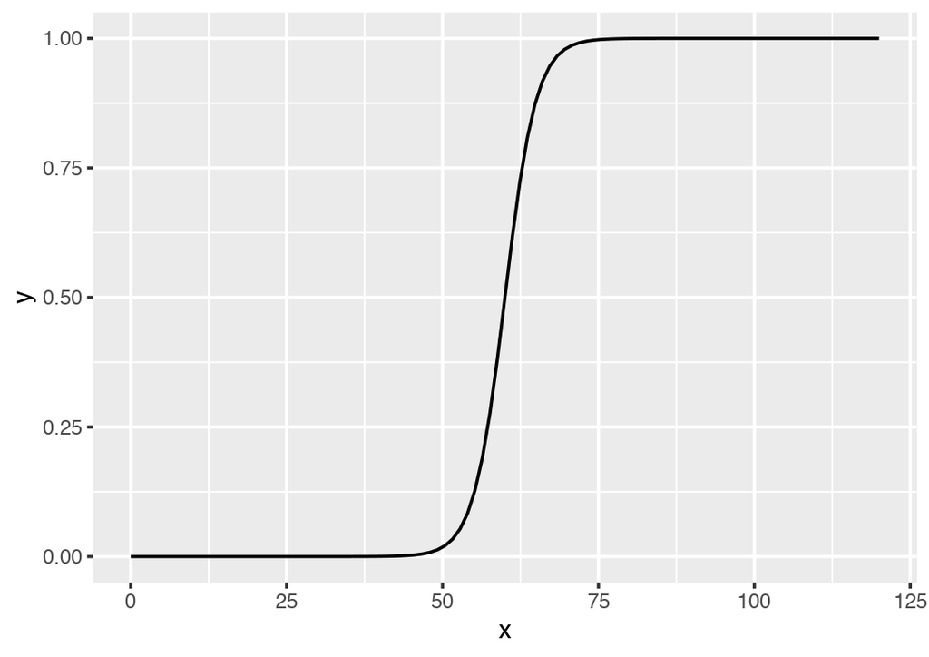

```r
ggplot(data.frame(x = c(0, 120)), aes(x = x)) +
  stat_function(fun = function(x) invlogit(-24 + 0.4 * x))
```

2. Suppose the midterm scores were transformed to have a mean of 0 and standard deviation of 1. What would be the equation of the logistic regression using these transformed scores as a predictor?

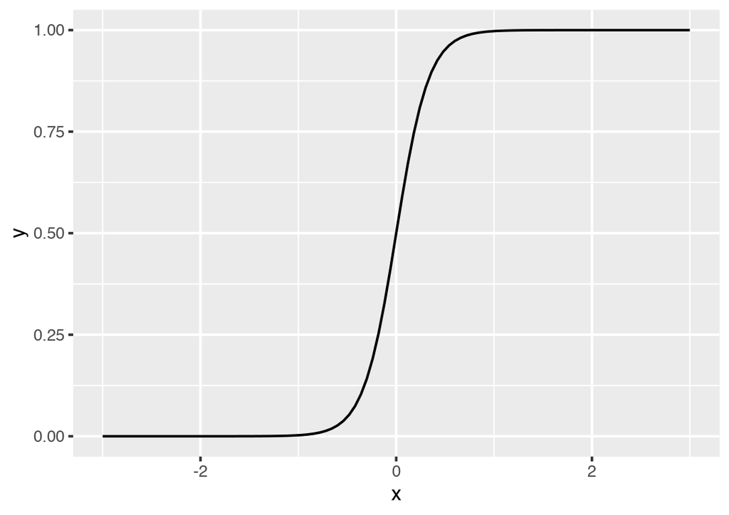

```r
ggplot(data = data.frame(x = c(-3, 3)), aes(x = x)) +
  stat_function(fun = function(x) invlogit(-24  + 0.4 * (15 * x + 60)))
```

3. Create a new predictor that is pure noise (for example, in R you can create `newpred <- rnorm (n,0,1)`). Add it to your model. How much does the deviance decrease?

```r
newpred <- rnorm (1747,0,1)
apt_dt$wn <- newpred
glm.apt.wn <- glm(formula = y ~ race +wn , data = apt_dt ,family = binomial(link = "logit"))
display(glm.apt)
```

```
## glm(formula = y ~ race, family = binomial(link = "logit"), data = apt_dt)
##                                coef.est coef.se
## (Intercept)                    -2.15     0.13
## raceBlack (non-hispanic)        1.54     0.17
## racePuerto Rican                1.45     0.21
## raceOther Hispanic              1.87     0.19
## raceAsian/Pacific Islander      0.40     0.29
## raceAmer-Indian/Native Alaskan  2.15     0.83
## raceTwo or more races           0.77     0.80
## ---
##   n = 1522, k = 7
##   residual deviance = 1518.7, null deviance = 1672.2 (difference = 153.5)
```

```r
display(glm.apt.wn)
```

```
## glm(formula = y ~ race + wn, family = binomial(link = "logit"),
##     data = apt_dt)
##                                coef.est coef.se
## (Intercept)                    -2.16     0.13
## raceBlack (non-hispanic)        1.54     0.17
## racePuerto Rican                1.45     0.21
## raceOther Hispanic              1.87     0.19
## raceAsian/Pacific Islander      0.41     0.29
## raceAmer-Indian/Native Alaskan  2.14     0.83
## raceTwo or more races           0.76     0.80
## wn                             -0.05     0.06
## ---
##   n = 1522, k = 8
##   residual deviance = 1518.1, null deviance = 1672.2 (difference = 154.1)
```

### Logistic regression

You are interested in how well the combined earnings of the parents in a child’s family predicts high school graduation. You are told that the probability a child graduates from high school is 27% for children whose parents earn no income and is 88% for children whose parents earn $60,000. Determine the logistic regression model that is consistent with this information. (For simplicity you may want to assume that income is measured in units of $10,000).

```r
intercept = logit(0.27)
coef1 = (logit(0.88)-intercept)/6
intercept
```

```
## [1] -0.9946226
```

```r
coef1
```

```
## [1] 0.4978421
```

$Pr(y=1)=logit^{-1}(-0.9946 + 0.4978*x)$

### Latent-data formulation of the logistic model:

take the model $Pr(y = 1) = logit^{-1}(1 + 2x_1 + 3x_2)$ and consider a person for whom $x_1 = 1$ and $x_2 = 0.5$. Sketch the distribution of the latent data for this person. Figure out the probability that $y=1$ for the person and shade the corresponding area on your graph.

```r
Pr = invlogit(1 + 2 * 1 + 3 * 0.5)
Pr
```

```
## [1] 0.9890131
```

### Limitations of logistic regression:

consider a dataset with $n = 20$ points, a single predictor x that takes on the values $1, \dots , 20$, and binary data $y$. Construct data values $y_{1}, \dots, y_{20}$ that are inconsistent with any logistic regression on $x$. Fit a logistic regression to these data, plot the data and fitted curve, and explain why you can say that the model does not fit the data.

### Identifiability:

the folder nes has data from the National Election Studies that were used in Section 5.1 of the Gelman and Hill to model vote preferences given income. When we try to fit a similar model using ethnicity as a predictor, we run into a problem. Here are fits from 1960, 1964, 1968, and 1972:

```
## glm(formula = vote_rep ~ female + black + income, family = binomial(link = "logit"),
##     data = nes5200_dt_d, subset = (year == 1960))
##             coef.est coef.se
## (Intercept) -0.16     0.23
## female       0.24     0.14
## black       -1.06     0.36
## income       0.03     0.06
## ---
##   n = 877, k = 4
##   residual deviance = 1202.6, null deviance = 1215.7 (difference = 13.1)
```

```
## glm(formula = vote_rep ~ female + black + income, family = binomial(link = "logit"),
##     data = nes5200_dt_d, subset = (year == 1964))
##             coef.est coef.se
## (Intercept)  -1.16     0.22
## female       -0.08     0.14
## black       -16.83   420.51
## income        0.19     0.06
## ---
##   n = 1062, k = 4
##   residual deviance = 1254.0, null deviance = 1337.7 (difference = 83.7)
```

```
## glm(formula = vote_rep ~ female + black + income, family = binomial(link = "logit"),
##     data = nes5200_dt_d, subset = (year == 1968))
##             coef.est coef.se
## (Intercept)  0.48     0.24
## female      -0.03     0.15
## black       -3.64     0.59
## income      -0.03     0.07
## ---
##   n = 851, k = 4
##   residual deviance = 1066.8, null deviance = 1173.8 (difference = 107.0)
```

```
## glm(formula = vote_rep ~ female + black + income, family = binomial(link = "logit"),
##     data = nes5200_dt_d, subset = (year == 1972))
##             coef.est coef.se
## (Intercept)  0.70     0.18
## female      -0.25     0.12
## black       -2.58     0.26
## income       0.08     0.05
## ---
##   n = 1518, k = 4
##   residual deviance = 1808.3, null deviance = 1973.8 (difference = 165.5)
```

What happened with the coefficient of black in 1964? Take a look at the data and figure out where this extreme estimate came from. What can be done to fit the model in 1964?

# Feedback comments etc.

If you have any comments about the homework, or the class, please write your feedback here. We love to hear your opinions.